# PatientLevelPrediction v5.0.0

2022-02-02

# Introduction

In PatientLevelPrediction v5.0.0 there has been changes to the way the data are extracted, the process to develop the model and the output objects. This document will describe the new code and describe the output objects.

For this document you will need to install the `Eunomia` package and the latest `PatientLevelPrediction` package by executing:

```r
## if you do not have devtools you will need it:
#install.packages('devtools')

## install Eunomia as this is used in the examples
# devtools::install_github('ohdsi/Eunomia')

## install PatientLevelPrediction
#devtools::install_github('ohdsi/PatientLevelPrediction',  ref = 'issue242')
```

To view the latest `PatientLevelPrediction` code see [GitHub Link](https://github.com/OHDSI/PatientLevelPrediction/tree/issue242)

# Code Structure Diagram

The interactions between the key functions in PatientLevelPrediction v5.0.0 are shown below.

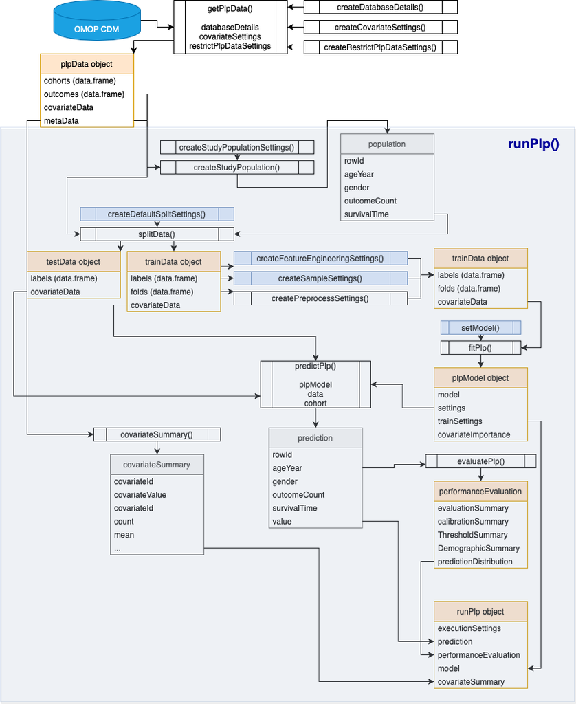

PatientLevelPrediction v5.0.0 code framework

# Data Extraction

The function used to extract the data is still named `getPlpData()` however the input to this function has changed. `getPlpData()` now requires three inputs:

The three inputs into getPlpData()

| inputs | descriptions |
| --- | --- |
| databaseDetails | An object of class databaseDetails containing the connection, schema and table names to the OMOP CDM database and database containing the cohorts. |
| covariateSettings | An object of class covariateSettings containing the settings for extracting the covariates (or a list of covariateSettings). |
| restrictPlpDataSettings | An object of class restrictPlpDataSettings containing inclusions criteria for the target cohort that is implemented during data extraction (such as data sampling, restricting to indexes occuring betwe… |

## Example Code To Extract Data

The `databaseDetails` object is created using the function `PatientLevelPrediction::createDatabaseDetails()`. It specifies the connectionDetails to the OMOP CDM you wish to extract data from as well as the schema, a shareable name for the OMOP CDM database and schema and table names where the target and outcome cohorts have been generated. To demonstrate this we will use the Eunomia package.

```r
# set up the connection
connectionDetails <- Eunomia::getEunomiaConnectionDetails()

# create the database
Eunomia::createCohorts(
  connectionDetails = connectionDetails,
  cdmDatabaseSchema = 'main',
  cohortDatabaseSchema = 'main',
  cohortTable = 'cohort'
  )
```

```
## Connecting using SQLite driver
```

```
## Creating cohort: Celecoxib
##
```

```
## Executing SQL took 0.0122 secs
```

```
## Creating cohort: Diclofenac
##
```

```
## Executing SQL took 0.0119 secs
```

```
## Creating cohort: GiBleed
##
```

```
## Executing SQL took 0.0204 secs
```

```
## Creating cohort: NSAIDs
##
```

```
## Executing SQL took 0.0929 secs
```

```
## Cohorts created in table main.cohort
```

```
##   cohortId       name
## 1        1  Celecoxib
## 2        2 Diclofenac
## 3        3    GiBleed
## 4        4     NSAIDs
##                                                                                        description
## 1    A simplified cohort definition for new users of celecoxib, designed specifically for Eunomia.
## 2    A simplified cohort definition for new users ofdiclofenac, designed specifically for Eunomia.
## 3 A simplified cohort definition for gastrointestinal bleeding, designed specifically for Eunomia.
## 4       A simplified cohort definition for new users of NSAIDs, designed specifically for Eunomia.
##   count
## 1  1844
## 2   850
## 3   479
## 4  2694
```

```r
# this creates cohorts
#      cohortId 1: Celecoxib
#      cohortId 2: Diclofenac
#      cohortId 3: GiBleed
#      cohortId 4: NSAIDs

databaseDetails <- PatientLevelPrediction::createDatabaseDetails(
  connectionDetails = connectionDetails,
  cdmDatabaseSchema = 'main',
  cdmDatabaseName = 'Eunomia',
  cohortDatabaseSchema = 'main',
  cohortTable = 'cohort',
  cohortId = 4,
  outcomeDatabaseSchema = 'main',
  outcomeTable = 'cohort',
  outcomeId = 3,
  cdmVersion = 5
  )
```

The covariateSettings objects can be created using the function `FeatureExtraction::createCovariateSettings()` or `PatientLevelPrediction::createCohortCovariateSettings()` or custom functions can be written to specify what covariates to extract. For example, to add standard covariates from `FeatureExtraction` that consist of age in 5-year buckets, gender and conditions/drugs using the era tables and vocabulary hierarchy that occur from 365 days until 1 day prior to the target index date:

```r
covariateSettings <- FeatureExtraction::createCovariateSettings(
  useDemographicsGender = T,
  useDemographicsAgeGroup = T,
  useConditionGroupEraLongTerm = T,
  useDrugGroupEraLongTerm = T,
  endDays = -1,
  longTermStartDays = -365
)
```

Finally, the restrictPlpDataSettings object is created using the `PatientLevelPrediction::createRestrictPlpDataSettings()`. This enables a user to specify any inclusions that can be done when downloading the data. This means it will not be possible to investigate the sensitivity of these inclusion criteria unless new data are extracted, but these settings can make data extraction quicker. To restrict to patients in the target population to those satisfying:

1. index date between Jan 1st 2000 and Jan 1st 2020
2. restrict to first occurrence in the target cohort
3. >= 30 days observation in database prior to index

then we can use the following settings:

```r
restrictPlpDataSettings <- PatientLevelPrediction::createRestrictPlpDataSettings(
  studyStartDate = '20000101',
  studyEndDate = '20200101',
  firstExposureOnly = T,
  washoutPeriod = 30
)

# issue with studyStartDate/studyEndDate
restrictPlpDataSettings <- PatientLevelPrediction::createRestrictPlpDataSettings(
  firstExposureOnly = T,
  washoutPeriod = 30
)
```

Putting this together, we can extract the plpData by executing:

```r
plpData <- PatientLevelPrediction::getPlpData(
  databaseDetails = databaseDetails,
  covariateSettings = covariateSettings,
  restrictPlpDataSettings = restrictPlpDataSettings
  )
```

```
## Connecting using SQLite driver
```

```
## Executing SQL took 0.0208 secs
```

```
## Constructing features on server
##
```

```
## Executing SQL took 0.931 secs
```

```
## Fetching data from server
## Fetching data took 0.19 secs
```

## plpData Structure

After successfully executing `PatientLevelPrediction::getPlpData` the object of class `plpData` is returned. This is a list containing the following components:

- cohorts: a data.frame with the columns ‘rowId’, ‘subjectId’, ‘cohortId’, ‘cohortStartDate’, ‘daysFromObsStart’, ‘daysToCohortEnd’, ‘daysToObsEnd’, ‘ageYear’, ‘gender’
- outcomes: a data.frame with the columns ‘rowId’, ‘outcomeId’, ‘daysToEvent’
- covariateData: an object of class CovariateData containing:
  - covariates: an andromeda object with the columns: ‘rowId’, ‘covariateId’, ‘covariateValue’
  - analysisRef: information about the analysisIds in the covariateRef
  - covariateRef: information about the covariates
- metaData: a list containing the databaseDetails (with the connection details removed), covariateSettings and restrictPlpDataSettings used to extract the data

**Useful exercise:** Run the example code above and play with the plpData object.

*Note:* The structure of `plpData` has not changed in v5.0.0, but the metaData object has been updated to store the new input settings.

# Model development and internal validation

The function use to develop the model and calculate the interval validation is still named `runPlp()` however the inputs have changed and the object returned by runPlp has also changed. `runPlp`()` now requires 13 inputs:

The inputs into runPlp()

| inputs | descriptions |
| --- | --- |
| plpData | An object of class plpData created using getPlpData(). |
| outcomeId | The cohort_definition_id for the outcome you want to predict. |
| analysisId | A unique identifier for the analysis |
| analysisName | A name for the analysis |
| populationSettings | An object of class populationSettings created using the createStudyPopulationSettings(). This specifies how the outcome labels are generated (the time at risk settings) and any exclusion criteria to a… |
| splitSettings | An object of class splitSettings created using createDefaultSplitSetting(). This specifies how the split the data into test/train/folds. |
| sampleSettings | (optional) An object of class sampleSettings created using createSampleSettings() or by a custom function. This can be used to over sample or under sample the patients in the data. |
| featureEngineeringSettings | (optional) An object of class featureEngineeringSettings create using createFeatureEngineeringSettings() or a custom function. This can be used to do feature selection or to create new features in the… |
| preprocessSettings | An object of class preprocessSettings created using createPreprocessSettings(). This specifies whether to normalize the features and whether to remove reduntant or rare features. |
| modelSettings | An object of class modelSettings created using one of the set functions or using a custom function. This specifies the machine learning algorithm to use to learn the prediction model and the hyper-par… |
| logSettings | An object of class logSettings created using createLogSettings(). This specifies the logging settings, such as verbosity. |
| executeSettings | An object of class executeSettings created using createExecuteSettings(). This specifies what part of the framework to apply (e.g., whether to do sampling or feature engineering). |
| saveDirectory | The directory to save the model and performance results |

## Example Code To Develop Model and Internally Validate

For this example we will develop a logistic regression model using the `setLassoLogisticRegression()` model settings to predict the outcome occuring 1 day after index until 2 years after index in patients who have not had the outcome prior to index:

```r
# create a population setting that labels people as having the outcome if
# they had the outcome recorded between 1 day after index and 730 days after
# index.  Remove people who had the outcome anytime prior (lookback 99999 days)
# and only include the earlier cohort entry (if a person is in cohort multiple times)
populationSettings <- PatientLevelPrediction::createStudyPopulationSettings(
  binary = T,
  includeAllOutcomes = F, # best practice showed this causes bias
  firstExposureOnly = T,
  washoutPeriod = 180,
  removeSubjectsWithPriorOutcome = T,
  priorOutcomeLookback = 99999,
  requireTimeAtRisk = F,
  riskWindowStart = 1,
  startAnchor = 'cohort start',
  riskWindowEnd = 365*2,
  endAnchor = 'cohort start'
)

# split into 25% test and 75% training data, use 3-fold cross validation
# random split but keep outcome rate the same in test/train
splitSettings <- PatientLevelPrediction::createDefaultSplitSetting(
  testFraction = 0.25,
  trainFraction = 0.75,
  splitSeed = 123,
  nfold = 3,
  type = 'stratified'
  )

# do no sampling
sampleSettings <- PatientLevelPrediction::createSampleSettings(
  type = 'none'
  )

# do no feature engineering
featureEngineeringSettings <- PatientLevelPrediction::createFeatureEngineeringSettings(
  type = 'none'
  )

# normalize features and remove any redundant ones
preprocessSettings <- PatientLevelPrediction::createPreprocessSettings(
  minFraction = 0,
  normalize = T,
  removeRedundancy = T
  )

logSettings <- PatientLevelPrediction::createLogSettings(verbosity = 'INFO')
```

```
## Use timeStamp: TRUE
```

```r
executeSettings <- PatientLevelPrediction::createExecuteSettings(
  runSplitData = T,
  runSampleData = F,
  runfeatureEngineering = F,
  runPreprocessData = T,
  runModelDevelopment = T,
  runCovariateSummary = T
  )

# use default LASSO logistic regression
modelSettings <- PatientLevelPrediction::setLassoLogisticRegression()

runPlp <- PatientLevelPrediction::runPlp(
  plpData = plpData,
  outcomeId = 3,
  analysisId = 'plp_demo',
  analysisName = 'Demonstrating the plp v5.0.0',
  populationSettings = populationSettings,
  splitSettings = splitSettings,
  sampleSettings = sampleSettings,
  featureEngineeringSettings = featureEngineeringSettings,
  preprocessSettings = preprocessSettings,
  modelSettings = modelSettings,
  logSettings = logSettings,
  executeSettings = executeSettings,
  saveDirectory = file.path(tempdir(), 'plp')
  )
```

```
## Creating save directory at: /var/folders/6s/ddvthmrj5p58pb5gchlns9ym0000gp/T//RtmpdLEys9/plp/plp_demo
## Patient-Level Prediction Package version 5.0.0
## Study started at: 2022-02-02 08:55:46
## AnalysisID:         plp_demo
## AnalysisName:       Demonstrating the plp v5.0.0
## CohortID:           4
## OutcomeID:          3
## Cohort size:        2630
## Covariates:         105
```

```
## Outcome is 0 or 1
## seed: 123
## Creating a 25% test and 75% train (into 3 folds) random stratified split by class
## Data split into 656 test cases and 1974 train cases (658, 658, 658)
## Train Set:
```

```
## Fold 1 658 patients with 120 outcomes - Fold 2 658 patients with 120 outcomes - Fold 3 658 patients with 120 outcomes
## 103 covariates in train data
## Test Set:
## 656 patients with 119 outcomes
## Removing 2 redundant covariates
## Normalizing covariates
## Tidying covariates took 0.445 secs
## Train Set:
```

```
## Fold 1 658 patients with 120 outcomes - Fold 2 658 patients with 120 outcomes - Fold 3 658 patients with 120 outcomes
## 101 covariates in train data
## Test Set:
## 656 patients with 119 outcomes
##
## Running Cyclops
## Done.
## GLM fit status:  OK
## Creating variable importance data frame
## Prediction took 0.0744 secs
## Removing infrequent and redundant covariates and normalizing
## Removing infrequent and redundant covariates covariates and normalizing took 0.222 secs
## Prediction took 0.0711 secs
## Calculating Performance for Test
## =============
## AUC                 57.32
## 95% lower AUC:      51.55
## 95% upper AUC:      63.10
## AUPRC:              22.81
## Brier:              0.15
```

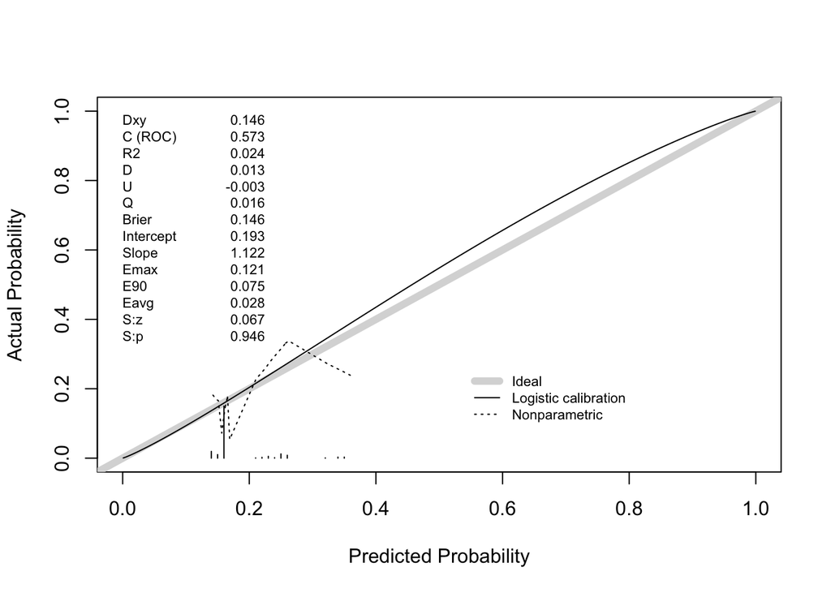

```
## Eavg:               0.03
## Calibration in large- Mean predicted risk 0.1798 : observed risk 0.1814
## Calibration in large- Intercept 0.0109
## Weak calibration intercept: 0.1928 - gradient:1.1216
## Hosmer-Lemeshow calibration gradient: 0.75 intercept:         0.05
## Average Precision:  0.23
## Calculating Performance for Train
## =============
## AUC                 59.34
## 95% lower AUC:      56.04
## 95% upper AUC:      62.63
## AUPRC:              24.57
## Brier:              0.15
```

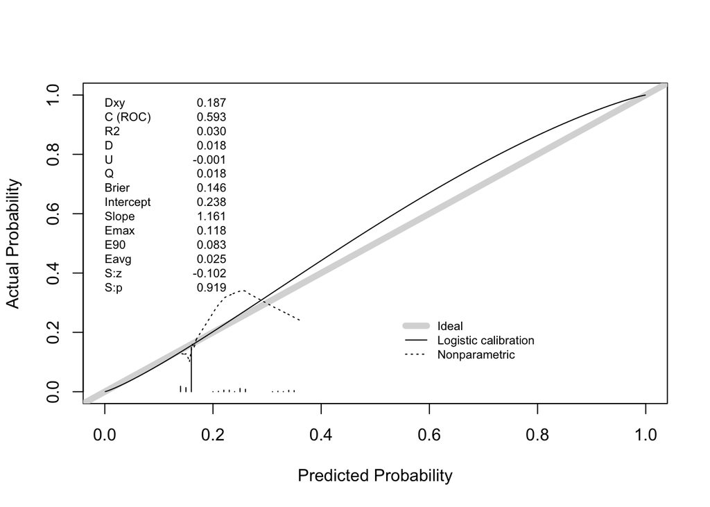

```
## Eavg:               0.03
## Calibration in large- Mean predicted risk 0.1824 : observed risk 0.1824
## Calibration in large- Intercept 0
## Weak calibration intercept: 0.238 - gradient:1.1615
## Hosmer-Lemeshow calibration gradient: 1.30 intercept:         -0.05
## Average Precision:  0.25
## Calculating Performance for CV
## =============
## AUC                 56.32
## 95% lower AUC:      52.85
## 95% upper AUC:      59.80
## AUPRC:              23.25
## Brier:              0.15
```

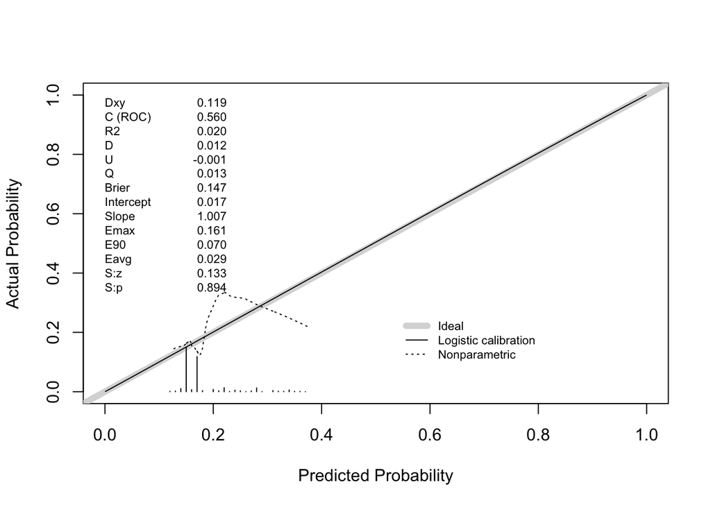

```
## Eavg:               0.03
## Calibration in large- Mean predicted risk 0.1814 : observed risk 0.1824
## Calibration in large- Intercept 0.0064
## Weak calibration intercept: 0.0165 - gradient:1.0068
## Hosmer-Lemeshow calibration gradient: 1.09 intercept:         -0.02
## Average Precision:  0.23
## Calculating covariate summary @ 2022-02-02 08:55:51
## This can take a while...
## Creating binary labels
## calculating subset of strata 1
## calculating subset of strata 2
## calculating subset of strata 3
## calculating subset of strata 4
## Restricting to subgroup
## Calculating summary for subgroup TrainWithNoOutcome
## Restricting to subgroup
## Calculating summary for subgroup TrainWithOutcome
## Restricting to subgroup
## Calculating summary for subgroup TestWithNoOutcome
## Restricting to subgroup
## Calculating summary for subgroup TestWithOutcome
## Aggregating with labels and strata
## Finished covariate summary @ 2022-02-02 08:55:51
## Run finished successfully.
## Saving PlpResult
## Creating directory to save model
## plpResult saved to ..\/var/folders/6s/ddvthmrj5p58pb5gchlns9ym0000gp/T//RtmpdLEys9/plp/plp_demo\plpResult
```

## runPlp Structure

If the function `runPlp()` executes successfully, then an object of class `runPlp` is returned. An object of class `runPlp` is a list containing:

- executionSummary: a list with details about the computer used to run the code, the execution date and versions of R and PatientLevelPrediction. This is useful when debugging issues.
- analysisRef: a list containing the analysisId and analysisName
- prediction: a data.frame including the columns: ‘rowId’, ‘value’, ‘evaluationType’
- covariateSummary: a data.frame with summary details about each of the candidate features (this is a characterization).
- performanceEvaluation: a list of performance objects (these are used to generate the performance plots)
- model: an object of class plpModel (this is described below)

In the sections below the prediction object, covariateSummary, performanceEvaluation and model objects are presented for the example using Eunomia.

### prediction Structure

The prediction object looks like:

```
##   rowId subjectId cohortId cohortStartDate daysFromObsStart
## 1     7         9        4      2014-08-05            13165
## 2    16        30        4      2009-03-23            14100
## 3    18        35        4      1997-05-02            13555
## 4    20        38        4      2006-05-20            15074
## 5    21        40        4      1993-07-12            15195
## 6    34        69        4      1984-08-02            14890
##   daysToCohortEnd daysToObsEnd ageYear gender outcomeCount timeAtRisk
## 1               0         1542      36   8532            0        730
## 2               0         3330      39   8532            0        730
## 3               0         7907      37   8532            1        730
## 4               0         4638      41   8532            0        730
## 5               0         9133      42   8507            0        730
## 6               0        12606      41   8507            0        730
##   daysToEvent survivalTime     value evaluationType
## 1          NA          730 0.1656860           Test
## 2          NA          730 0.1620460           Test
## 3          84           84 0.2575511           Test
## 4          NA          730 0.1653540           Test
## 5          NA          730 0.1653540           Test
## 6          NA          730 0.1653540           Test
```

### covariateSummary Structure

The covariateSummary object is a tibble that looks like:

```
## # A tibble: 6 × 27
##   covariateId covariateName             analysisId conceptId CovariateCount
##         <dbl> <chr>                          <int>     <int>          <int>
## 1  4285898210 condition_era group duri…        210   4285898            375
## 2   372328210 condition_era group duri…        210    372328             13
## 3  4283893210 condition_era group duri…        210   4283893            329
## 4   260139210 condition_era group duri…        210    260139            124
## 5 40481087210 condition_era group duri…        210  40481087            286
## 6  4218389210 condition_era group duri…        210   4218389             14
## # … with 22 more variables: CovariateMean <dbl>, CovariateStDev <dbl>,
## #   WithNoOutcome_CovariateCount <dbl>, WithNoOutcome_CovariateMean <dbl>,
## #   WithNoOutcome_CovariateStDev <dbl>, WithOutcome_CovariateCount <dbl>,
## #   WithOutcome_CovariateMean <dbl>, WithOutcome_CovariateStDev <dbl>,
## #   StandardizedMeanDiff <dbl>, TrainWithNoOutcome_CovariateCount <dbl>,
## #   TrainWithNoOutcome_CovariateMean <dbl>,
## #   TrainWithNoOutcome_CovariateStDev <dbl>, …
```

The contents is largely unchanged in v5.0.0 but the column names are slightly different.

### performanceEvaluation Structure

The performanceEvaluation contains five objects:

The `evaluationStatistics` which is a data.frame containing summary performance metrics such as AUROC and the e-statistics per evaluation type:

```
##   evaluation          metric             value
## 1       Test  populationSize               656
## 2       Test    outcomeCount               119
## 3       Test           AUROC         0.5732438
## 4       Test 95% lower AUROC         0.5154849
## 5       Test 95% upper AUROC         0.6310028
## 6       Test           AUPRC 0.228137246071622
```

The `thresholdSummary` which is a data.frame containing the operating characteristics of the model (per evaluation type) at various threshold cut-offs:

```
##   evaluation predictionThreshold sensitivity specificity
## 1       Test           0.3594432 0.000000000   0.9981378
## 2       Test           0.3533493 0.000000000   0.9832402
## 3       Test           0.3499759 0.008403361   0.9832402
## 4       Test           0.3478478 0.033613445   0.9739292
## 5       Test           0.3234775 0.042016807   0.9720670
## 6       Test           0.2673705 0.050420168   0.9664804
##   positivePredictiveValue
## 1               0.0000000
## 2               0.0000000
## 3               0.1000000
## 4               0.2222222
## 5               0.2500000
## 6               0.2500000
```

The `calibrationSummary` which is a data.frame containing the mean predicted risk and observed risk for different groups partitioned based on predicted risk:

```
##   predictionThreshold PersonCountAtRisk PersonCountWithOutcome
## 1           0.0000000                59                     11
## 2           0.1509518                18                      1
## 3           0.1565076                13                      2
## 4           0.1597241                 3                      0
## 5           0.1600470               227                     34
## 6           0.1620460                 2                      0
##   averagePredictedProbability StDevPredictedProbability
## 1                   0.1473090               0.001441767
## 2                   0.1556098               0.002065801
## 3                   0.1597241               0.000000000
## 4                   0.1600470               0.000000000
## 5                   0.1620460               0.000000000
## 6                   0.1633221               0.000000000
##   MinPredictedProbability P25PredictedProbability
```

[output cut: 20 more lines]

The `demographicSummary` which is a data.frame containing the mean predicted risk and observed risk for different age/gender groups. This tells you how well calibrated the model is for each age/gender subgroup:

```
##           ageGroup genGroup PersonCountAtRisk PersonCountWithOutcome
## 1 Age group: 30-34   Female                40                      8
## 2 Age group: 30-34     Male                32                      5
## 3 Age group: 35-39   Female               171                     34
## 4 Age group: 35-39     Male               157                     26
## 5 Age group: 40-44   Female               127                     18
## 6 Age group: 40-44     Male               109                     21
##   averagePredictedProbability StDevPredictedProbability
## 1                   0.1597307                0.03000999
## 2                   0.1638721                0.04691862
## 3                   0.1784329                0.03793505
## 4                   0.1824396                0.04487447
## 5                   0.1848971                0.04763965
## 6                   0.1840465                0.04527860
##   MinPredictedProbability P25PredictedProbability P50PredictedProbability
## 1               0.1426112                0.147744                0.147744
## 2               0.1426112                0.147744                0.147744
## 3               0.1565076                0.162046                0.162046
## 4               0.1565076                0.162046                0.162046
## 5               0.1597241                0.165354                0.165354
## 6               0.1597241                0.165354                0.165354
##   P75PredictedProbability MaxPredictedProbability evaluation
## 1               0.1477440               0.2420466       Test
## 2               0.1477440               0.3234775       Test
## 3               0.1656860               0.3478478       Test
## 4               0.1656860               0.3478478       Test
## 5               0.1690533               0.3594432       Test
## 6               0.1653540               0.3533493       Test
```

The `predictionDistribution` which is a data.frame containing the summary distribution of predicted risk for those with the outcome (class 1) and those without the outcome (class 0)

```
##   class PersonCount averagePredictedProbability StDevPredictedProbability
## 1     0         537                   0.1772500                0.04144569
## 2     1         119                   0.1913490                0.05100167
## 3     0        1614                   0.1792672                0.04520129
## 4     1         360                   0.1962869                0.05489037
## 5     0        1614                   0.1790408                0.04288310
## 6     1         360                   0.1921120                0.05147809
##   MinPredictedProbability P05PredictedProbability P25PredictedProbability
## 1               0.1426112               0.1477440               0.1620460
## 2               0.1477440               0.1477440               0.1620460
## 3               0.1426112               0.1477440               0.1620460
## 4               0.1426112               0.1477440               0.1620460
## 5               0.1278352               0.1505188               0.1596117
## 6               0.1272067               0.1512425               0.1596117
##   MedianPredictedProbability P75PredictedProbability
## 1                  0.1620460               0.1653540
## 2                  0.1653540               0.2334923
## 3                  0.1620460               0.1653540
## 4                  0.1653540               0.2334923
## 5                  0.1700073               0.1706294
## 6                  0.1706294               0.2209852
##   P95PredictedProbability MaxPredictedProbability evaluation
## 1               0.2621986               0.3594432       Test
## 2               0.2631346               0.3499759       Test
## 3               0.2626639               0.3594432      Train
## 4               0.3297789               0.3594432      Train
## 5               0.2801468               0.3619147         CV
## 6               0.3135904               0.3776930         CV
```

**Note**: The main difference between the old results and the new results is the addition of the CV evaluation type. The functions that generate the evaluation performance were updated to calculate the performances per evaluation type.

The plot functions in `PatientLevelPrediction` generally use the `performanceEvaluation`. These have been updated in v5.0.0. Previously you were required to specify the type of evaluation to plot, now the plots iterative through the evaluation types and generate a plot per type. Below are the examples for plotting the ROC plots and the demographic calibration plots:

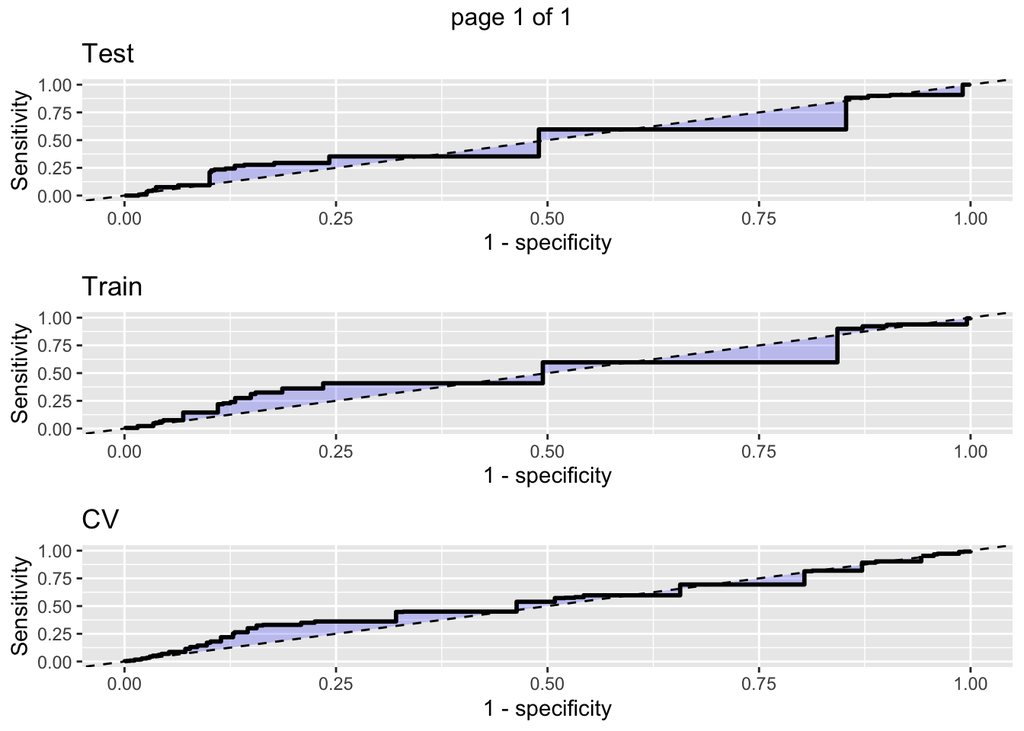

```r
PatientLevelPrediction::plotSparseRoc(runPlp)
```

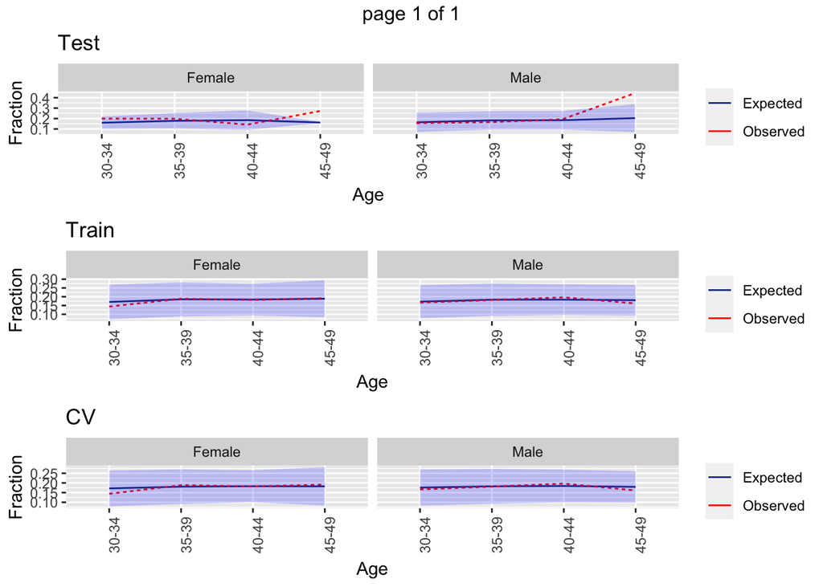

```r
PatientLevelPrediction::plotDemographicSummary(runPlp)
```

### model Structure

The model is an object of class `plpModel`. The class `plpModel` structure has changed in PatientLevelPrediction v5.0.0. The new `plpModel` class is a list with the following structure:

- Model: a pointer to where the model is saved or a list with the model
- settings: a list containing:
  - plpDataSettings: the plpDataSettings settings input to getPlpData()
  - covariateSettings: the covariateSettings input to getPlpData()
  - populationSettings: the populationSettings
  - featureEngineering: the featureEngineeringSettings
  - tidyCovariates the output of preprocessSettings
    - populationSize: integer
    - deletedRedundantCovariateIds: vector of covariateIds
    - deletedInfrequentCovariateIds: vector of covariateIds (can be large)
    - normFactors: tibble with columns: covariateId and maxValue (can be large)
  - requireDenseMatrix – logical
  - modelSettings - the modelSettings
  - splitSettings - the splitSettings
  - sampleSettings - the sampleSettings
- trainDetails: a list with:
  - analysisId: the analysisId that was input
  - analysisSource: (not currently in)
  - cdmDatabaseSchema: the cdmDatabaseSchema from the databaseDetails
  - outcomeId: the outcomeId from the populationSettings
  - cohortId: the cohortId from the databaseDetails
  - attrition: a data.frame with the number of people remaining after each exclusion criteria in the study population creation
  - trainingTime: time taken to develop the model
  - trainingDate: the date the model was developed
  - hyperParamSearch: a data.frame with the hyper-parameter search details
- covariateImportance: a data.frame with 7 columns (can be large): This tells you the column id for each covariateId

The `plpModel` must also have the attributes:

- predictionFunction: A character specifying the function used to make prediction with this model
- modelType: either ‘binary’/‘survival’
- saveType: either ‘RtoJson’/‘file’/‘xgboost’ (used when saving the model)

**Exercise**: execute runPlp() with your choice of settings. If it works explore the results. If it fails, let me know so we can fix it, we did this tutorial to hack the code and find some bugs…

# Built in preprocessing functions

Here are the list of the current built in functions for the [sampling](https://github.com/OHDSI/PatientLevelPrediction/blob/issue242/R/Sampling.R), [feature engineering](https://github.com/OHDSI/PatientLevelPrediction/blob/issue242/R/FeatureEngineering.R) and [data splitting](https://github.com/OHDSI/PatientLevelPrediction/blob/issue242/R/DataSplitting.R). These can all be customized (there are documents in the `PatientLevelPrediction` vignettes folder).

The functions that are in the package

| functionName | type | descriptions |
| --- | --- | --- |
| createDefaultSplitSetting() | Splitting | Does the outcome stratified, by subject or temporal split test/train sets with cross validation |
| createFeatureEngineeringSettings() | Feature Engineering | Currently does nothing |
| createUnivariateFeatureSelection() | Feature Engineering | Picks features that are most correlated to the outcome. This is useful if using Naive Bayes as the model. |
| createRandomForestFeatureSelection() | Feature Engineering | Applies a random forest and picks the variables with the highest feature importance. This is useful if using random forest as the model. |
| createSampleSettings() | Sampling | Currently gives the option to do none or under sample |

# Built in models

Here are the list of the current models. Custom models can be written and added.

The models that are in the package

| functionName | type |
| --- | --- |
| setAdaBoost() | Binary Classification |
| setCoxModel() | Survival Model |
| setDecisionTree() | Binary Classification |
| setGradientBoostingMachine() | Binary Classification |
| setIterativeHardThresholding() | Binary Classification |
| setKNN() | Binary Classification |
| setLassoLogisticRegression() | Binary Classification |
| setMLP | Binary Classification |
| setNaiveBayes | Binary Classification |
| setRandomForest | Binary Classification |
| setSVM | Binary Classification |

The deep learning and ensemble learning have moved to seperate packages.